# Exploring space policies in the STIP Compass

*Marit Undseth*  
31<sup>st</sup> July, 2024

[figure not shown]

**The thematic STIP portal for space policies is a one-stop shop for decision makers, researchers, and other stakeholders interested in comparative policy analysis of the space economy. It comprises policy initiatives and instruments from economies on five continents and has a wide thematic range spanning from R&D funding to innovation prizes. The portal is maintained by the OECD Space Forum with kind support from its members.**

More governments than ever before are engaged in space activities. Space systems are important for national security and defence, they ensure the secure operation of transportation, energy and finance infrastructures and provide important inputs to public safety and food supply. Recent reductions in the cost of access to space, thanks to system standardisation and miniaturisation and increased reusability, are also democratising access and creating opportunities for new and smaller actors. Finally, the announcement and deployment of several mega constellations for satellite broadband, comprising thousands of satellites in low-earth orbit, has created considerable optimism for future market prospects.

The thematic STIP Compass portal for space policies presents the multiple ways governments fund, support, manage and co-ordinate space activities and nurture the space innovation ecosystem from an STI perspective. As of April 2024, the portal included 165 policy initiatives from more than 30 economies and international organisations on five continents. The portal brings insights on the main policy initiatives adopted by governments by country/territory, by policy theme and by policy instrument. Several space-related OECD indicators are also included under each theme, with full access to datasets. The portal relies on the underlying taxonomy of the STIP Compass, but initiatives are classified according to six specific space-related themes:

- National strategies and policy co-ordination
- International co-operation
- Support for public R&D and infrastructures
- Support for business R&D and innovation
- Space technology transfer and commercialisation
- Human resources and STEM

**Figure 1. Space-related policies serve multiple purposes: Count of initiatives and instruments.**

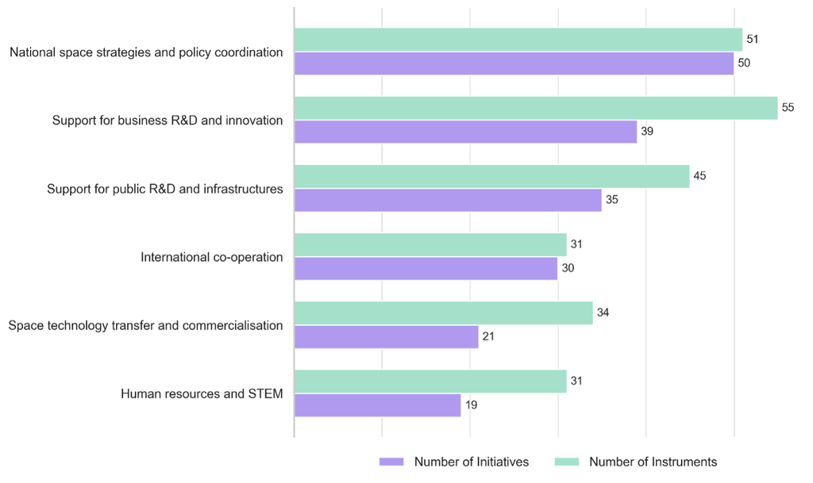

Notes: (1) An STI policy initiative can be defined as a public action that i) aims to achieve one or several public policy goals in the policy area of science, technology and innovation, ii) is expected to modify or frame the behaviours of actors and stakeholders, being national, domestic or foreign, who are part of or influential on, the national innovation system, and iii) is implemented with a minimum time horizon or on a continuous basis (i.e. not as a one-off "event"). A policy initiative uses one or more policy instruments in its implementation. (2)Initiatives can be listed in more than one thematic category.

**Source:** EC-OECD (2024), STIP Compass: International Database on Science, Technology and Innovation Policy (STIP), downloaded on April 15, 2024, https://stip.oecd.org

### [National strategies and policy co-ordination](https://stip.oecd.org/stip/space-portal/themes/THs1)

Strategy documents are the most common type of space-related policy instruments in the thematic portal, reflecting the growing importance of space activities at the government level. They articulate governments’ visions regarding the contribution of space activities to social and economic development. They set priorities for public investment in space activities and identify the focus of government reforms, for instance, in areas such as funding of public research and promoting business innovation. Space activities have traditionally had a strong public research profile, for example in countries such as France and the United States. But governments also increasingly appreciate the role of space in economic growth, notably the private sector’s contribution to innovation and entrepreneurship. This approach can be found in the strategies of Germany, Norway and Canada, for instance.

Meanwhile, space programmes span across different domains of governmental responsibilities, such as research, communications, defence and economic development. To map existing capabilities and better co-ordinate future efforts, governments are increasingly setting up different types of coordination bodies, with space agencies recently created in Poland and Portugal, for instance, or the [French state-industry space co-ordination committee COSPACE](https://stip.oecd.org/stip/space-portal/policy-initiatives/2023%2Fdata%2FpolicyInitiatives%2F99994579).

**Figure 2: Strategies, agendas and plans are the most common policy instruments in thematic portal for space policies**

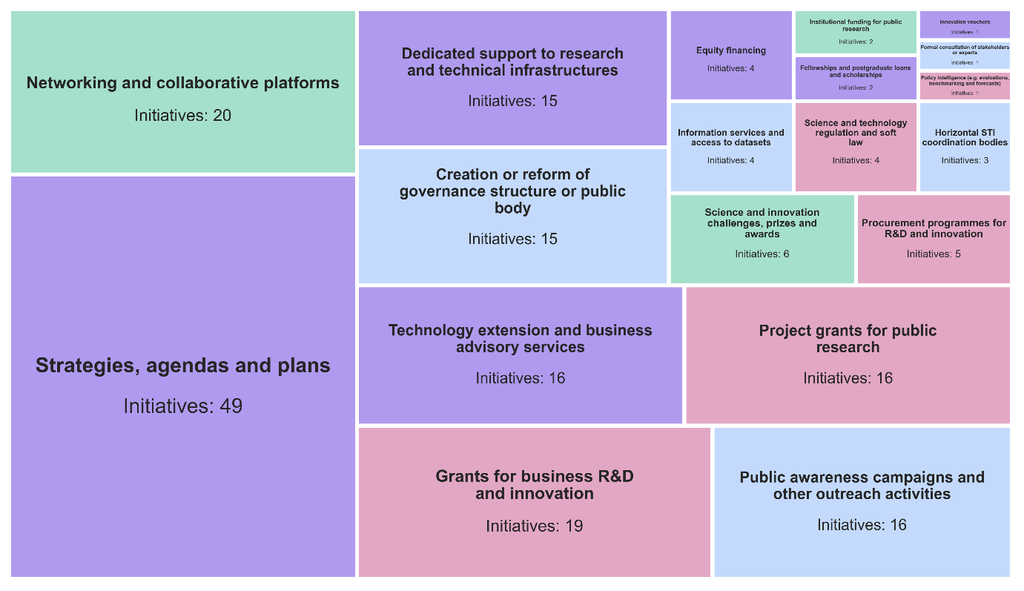

**Source:** EC-OECD (2024), STIP Compass: International Database on Science, Technology and Innovation Policy (STIP), downloaded on April 15, 2024, https://stip.oecd.org

### [International co-operation](https://stip.oecd.org/stip/space-portal/themes/THs2)

Space industrial and R&D activities are characterised by a high level of international co-operation, to pool the resources of multiple national actors, to enable access to international research communities and to expand markets for domestic industry. In Europe, international organisations such as the European Space Agency, Eumetsat and increasingly also the European Union play an important role in managing and co-ordinating space programmes for science, Earth observation and satellite navigation.

There are therefore multiple bilateral and multilateral agreements at different levels of co-operation in the space sector, ranging from memorandums of understanding on information exchange to membership in international organisations, and covering several thematic areas (e.g. science, space education). The European Space Agency is the de facto space agency for several smaller European countries.

### [Support for public R&D and infrastructures](https://stip.oecd.org/stip/space-portal/themes/THs3)

A significant share of basic and applied R&D in the space domain is funded and performed by public actors, particularly in higher education institutions and in public research organisations. Competitive and non-competitive research funding are therefore important instruments.

The prominent role of physical and digital public research infrastructure is another specific characteristic of space-related STI policies, involving dedicated support of such structures, measures that facilitate the use of them by third parties, and the management and diffusion of satellite data.

Public facilities, in particular, play an important role for space technology prototype development and flight qualification. Extensive ground testing is often required (e.g. testing for radiation and temperature), as well as tests and technology demonstrations in the orbital environment. Several space agencies provide access to facilities and spaceflight for research and technology development. One example is the [NASA Flight Opportunities programme for researchers](https://stip.oecd.org/stip/space-portal/policy-initiatives/2023%2Fdata%2FpolicyInitiatives%2F99994610) in the United States.

Finally, there are multiple government initiatives linked to open science and enhanced access to government satellite data. The volume and variety of satellite data and signals have increased exponentially in recent years, as have the digital tools and technologies to exploit them. Access has been greatly facilitated by dedicated platforms developed by space agencies and other administrations, and government data are increasingly available via open data policies. Examples include [Digital Earth Australia](https://stip.oecd.org/stip/space-portal/policy-initiatives/2023%2Fdata%2FpolicyInitiatives%2F99994410), the [National Ground Segment for Satellite Data in Norway](https://stip.oecd.org/stip/space-portal/policy-initiatives/2023%2Fdata%2FpolicyInitiatives%2F99994593), and the [Satellite Data Portal in the Netherlands](https://stip.oecd.org/stip/space-portal/policy-initiatives/2023%2Fdata%2FpolicyInitiatives%2F99994570).

### [Support for business R&D and innovation](https://stip.oecd.org/stip/space-portal/themes/THs4)

In most OECD countries, the private sector has been an integral part of space sector development since the beginning of the modern space age in the 1950s and 1960s, providing R&D, equipment, components, and services. More recently, there has been a shift in space policy priorities, with a stronger focus on fostering entrepreneurship, innovation, and commercialisation. This translates into a more diverse portfolio of policy initiatives and instruments, ranging from R&D procurement and subsidies to seed funding and business incubation. The European Space Agency, for example, has a network of business incubation centres in several European countries, providing services such as technical support, business coaching, and equity funding.

Financing space technology development can be a particular challenge because of the combination of high development cost and considerable technology risk. In a recent development, several countries are improving access to venture capital for space start-ups, with dedicated funds in France, Italy, and Luxembourg, and at the international level with the [CASSINI space entrepreneurship initiative](https://stip.oecd.org/stip/space-portal/policy-initiatives/2023%2Fdata%2FpolicyInitiatives%2F99994681) of the European Union.

### [Space technology transfer and commercialisation](https://stip.oecd.org/stip/space-portal/themes/THs5)

Space-related R&D is to a great extent funded and/or performed by public organisations or higher education institutions. Over the last decades, the contributions of transfers and commercialisations of publicly-funded space technology to innovation, growth, and job creation have become increasingly recognised. Governments in OECD countries and other economies therefore encourage such technology transfers through a wide and diverse range of measures that target science-industry knowledge transfer and sharing, such as the [German INNOspace initiative](https://stip.oecd.org/stip/space-portal/policy-initiatives/2023%2Fdata%2FpolicyInitiatives%2F99994581), the commercialisation of research (e.g. the [UK Satellite Applications Catapult](https://stip.oecd.org/stip/space-portal/policy-initiatives/2023%2Fdata%2FpolicyInitiatives%2F99994574)), and the formation of clusters and collaborative R&D programmes and centres (such as the [Australian SmartSat Cooperative Research Centre](https://stip.oecd.org/stip/space-portal/policy-initiatives/2023%2Fdata%2FpolicyInitiatives%2F99994599) or the [French Spaceship initiative](https://stip.oecd.org/stip/space-portal/policy-initiatives/2023%2Fdata%2FpolicyInitiatives%2F99994827)).

Hackathons and prizes are increasingly used to identify innovative and commercially viable applications of publicly-funded technology and data, with the [ActInSpace innovation contest](https://stip.oecd.org/stip/space-portal/policy-initiatives/2023%2Fdata%2FpolicyInitiatives%2F99994578), initiated by France, as one of the most notable examples.

### [Human resources and STEM](https://stip.oecd.org/stip/space-portal/themes/THs6)

Like for several other high-technology sectors, the space sector faces strong structural challenges in human capital, such as science, technology, engineering, and mathematics (STEM)-related constraints and a notable gender gap in scientific and management occupations. The supply of university graduates in several space-related scientific disciplines (e.g., aerospace engineering), and STEM disciplines more generally, has not kept up with demand in several OECD countries.

Government efforts in this area tend to focus on nurturing STEM skills in the younger generations, through the specific lens of space exploration and other activities. Instruments include [summer schools](https://stip.oecd.org/stip/space-portal/policy-initiatives/2023%2Fdata%2FpolicyInitiatives%2F2272) (Austria); [educational workshops, resources and teacher training](https://stip.oecd.org/stip/space-portal/policy-initiatives/2023%2Fdata%2FpolicyInitiatives%2F24525) (e.g., Belgium, European Space Agency, Türkiye); and [student scholarships and fellowships](https://stip.oecd.org/stip/space-portal/policy-initiatives/2023%2Fdata%2FpolicyInitiatives%2F25128) (NASA Space Grant in the United States).

Many of the initiatives are also associated with public outreach, building on the inspirational effects of space activities. Examples include [space discovery centres](https://stip.oecd.org/stip/space-portal/policy-initiatives/2023%2Fdata%2FpolicyInitiatives%2F24721) (Australia), awareness-raising events such as the [Space Week](https://stip.oecd.org/stip/space-portal/policy-initiatives/2023%2Fdata%2FpolicyInitiatives%2F25349) in Malta or the national science festival [Spaceship Earth](https://stip.oecd.org/stip/space-portal/policy-initiatives/2023%2Fdata%2FpolicyInitiatives%2F24436) in Lithuania.

### About the OECD Space Forum

The thematic **STIP Compass portal for space policies** allows monitoring and comparing space policies internationally, at a time of considerable change and innovation in this policy domain. The [OECD Space Forum](https://www.oecd.org/en/networks/space-forum.html) will continue its efforts to update and expand this thematic portal for improved coverage and analysis. This ongoing commitment aims to provide decision makers and stakeholders with insights and data, fostering informed policy making that can effectively respond to emerging challenges and opportunities. By continuously enhancing the repository of knowledge and facilitating international collaboration, the OECD Space Forum aspires to support the sustainable growth and advancement of the global space economy, ensuring that the benefits of space activities are maximised and shared across different economies.